# Analisis y Visualización sobre DFs de Sarcasmo y No Sarcasmo

```python
import nltk
import numpy as np
import pandas as pd
import seaborn as sn

from nltk.corpus import stopwords
from nltk.tokenize import word_tokenize
from nltk.stem import WordNetLemmatizer

nltk.download('stopwords')
nltk.download('punkt')
nltk.download('wordnet')
nltk.download('averaged_perceptron_tagger')
```

```
True
```

Unimos todos los dataframes para trabajar directamente con todos los datos con los que disponemos

```python
df0 = pd.read_csv("./sarcasm_v2/GEN-sarc-notsarc.csv")
df1 = pd.read_csv("./sarcasm_v2/HYP-sarc-notsarc.csv")
df2 = pd.read_csv("./sarcasm_v2/RQ-sarc-notsarc.csv")

df = pd.concat([df0, df1, df2], ignore_index=True)
```

# Analisis de palabras más comunes.

Primero definamos funciones que nos van a servir.

```python
flatten_list = lambda nested_list: [
    el for sublist in nested_list for el in sublist]

lemmatizer = WordNetLemmatizer()
get_lemm_tokens = lambda tokens: [lemmatizer.lemmatize(t) for t in tokens]

get_token_freq = lambda tokens: nltk.FreqDist(tokens)

stop_words = set(stopwords.words('english'))
rm_stop_words = lambda tokens: [t for t in tokens if t not in stop_words]
```

```python
def compare_freq(most_common_freq, cmp_freq,
                 mc_label, cmp_label,
                 mc_color, cmp_color):
    """
    This function compares the frequency of the most common tokens
    of `most_common_freq` with the frequency they have in `cmp_freq`.
    """
    most_common = most_common_freq.most_common(30)

    most_common_words = [x for x, y in most_common]
    most_common_freqs = [y/len(most_common_freq) for x, y in most_common]

    cmp_freq_in_mc = [cmp_freq[x]/len(cmp_freq) for x, y in most_common]

    most_common = sn.lineplot(
        x=most_common_words,
        y=cmp_freq_in_mc,
        label=cmp_label,
        sort=False,
        color=cmp_color
    )
    not_sarc_gr = sn.lineplot(
        x=most_common_words,
        y=most_common_freqs,
        label=mc_label,
        sort=False,
        color=mc_color
    )
    rot_lab_ns = most_common.set_xticklabels(
        labels=most_common_words, rotation=90)
```

Definamos variables que también serán de utilidad.

```python
sarc_df = df["sarc" == df["class"]]
not_sarc_df = df["notsarc" == df["class"]]
```

```python
sarc_token_texts = [nltk.word_tokenize(snts) for snts in sarc_df['text']]
not_sarc_token_texts = [
    nltk.word_tokenize(snts) for snts in not_sarc_df['text']]
```

```python
sarc_token_list = flatten_list(sarc_token_texts)
not_sarc_token_list = flatten_list(not_sarc_token_texts)
```

```python
lower_sarc_tokens = [token.lower() for token in sarc_token_list]
lower_not_sarc_tokens = [token.lower() for token in not_sarc_token_list]
```

```python
sarc_token_freq = get_token_freq(lower_sarc_tokens)
not_sarc_token_freq = get_token_freq(lower_not_sarc_tokens)
```

Veamos los primeros analisis

Palabras mas frecuentes en textos con sarcasmo:

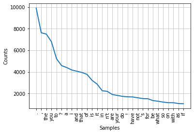

```python
sarc_token_freq.plot(30, cumulative=False)
```

Palabras mas frecuentes en textos sin sarcasmo:

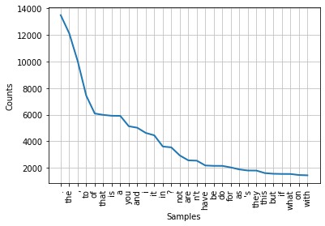

```python
not_sarc_token_freq.plot(30, cumulative=False)
```

Si comparamos ambos gráficos podemos ver como articulos como "the", "and" o símbolos como el signo de puntuación o el apóstrofe, aparecen prácticamente con la misma frecuencia en ambos casos, por lo cuál no nos darían información relevante al análisis de sarcasmo.

Ahora pasaremos a realizar una comparación gráfica entre la frecuencia de las palabras en textos sarcasticos y no sarcasticos, donde podremos visualizar más facilmente relaciones, picos y diferencias entre palabras en ambos tipos de textos

Palabras más frecuentes en textos con sarcasmo comparadas con la frecuencia de las mismas en textos sin sarcasmo:

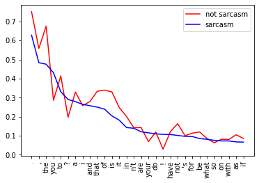

```python
compare_freq(
    sarc_token_freq, not_sarc_token_freq,
    "sarcasm", "not sarcasm",
    "blue", "red",
)
```

Palabras más frecuentes en textos sin sarcasmo comparadas con la frecuencia de las mismas en textos con sarcasmo:

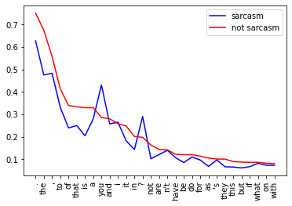

```python
compare_freq(
    not_sarc_token_freq, sarc_token_freq,
    "not sarcasm", "sarcasm",
    "red", "blue",
)
```

Observamos que en los textos de sarcasmo, palabras como "you", y signos de excalamación ("!"), o pregunta ("?"), experimentan picos de crecimiento, por sobre las mismas palabras en los textos de no sarcasmo. Es decir, se repiten con mas frecuencia en los textos de Sarcasmo. Con esta información, podemos realizar dos hipótesis, que iremos contrarestando a lo largo del trabajo. Hipótesis 1): el uso de la palabra "you" con frecuencia se debe a que las personas sercástics se refieren a otras personas cuando hacen comentarios de este tipo. Los signos de admiración se emplean en los comentarios sarcásticos ya que son comentarios efusivos, hechos con emocionalidad. Los signos de interrogación se repiten mas en los textos sarcásticos ya que la mayoría de estos comentarios son hechos en modo de pregunta hacia otra persona. Hipótesis 2): los datos están sucios por signos de admiración y puntuación que no corresponden al comentario original, o que no representan énfasis o interrogación en el comentario.

```python
print(
    "! in not sarcsm: {}\n".format(not_sarc_token_freq['!']),
    "! in sarcsm: {}\n".format(sarc_token_freq['!']),
    "# of sarcastic tokens: {}\n".format(len(sarc_token_freq)),
    "# of non sarcastic tokens {}\n".format(len(not_sarc_token_freq))
)
```

```
! in not sarcsm: 526
 ! in sarcsm: 1692
 # of sarcastic tokens: 15787
 # of non sarcastic tokens 17966
```

Tomando como ejemplo el signo de admiración, podemos ver como aparece triplicado en los textos de sarcasmo, si lo comparamos con el numero de veces que aparece en los textos de no sarcasmo. Además, la cantidad de palabras dentro de los textos con sarcasmo es menor, por lo cuál resulta importante destacar que el signo de admiración aparece triplicado en una menor cantidad total de palabras.

## Analisis con lematización

Con la lematizacion se intenta llegar a la raíz de cada palabra, de manera tal que tengamos una familia de palabras para cada texto (sarc y no sarc), donde cada familia contenga todas las palabras dentro de si misma. Luego compararemos cada familia de palabras para ver sus similitudes y diferencias.

```python
sarc_lemm_tokens = get_lemm_tokens(sarc_token_list)
not_sarc_lemm_tokens = get_lemm_tokens(not_sarc_token_list)
```

```python
sarc_lemm_freq = get_token_freq(lower_sarc_tokens)
not_sarc_lemm_freq = get_token_freq(lower_not_sarc_tokens)
```

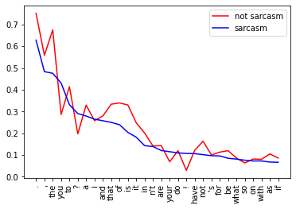

```python
compare_freq(
    sarc_lemm_freq, not_sarc_lemm_freq,
    "sarcasm", "not sarcasm",
    "blue", "red",
)
```

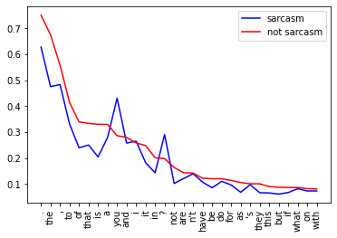

```python
compare_freq(
    not_sarc_lemm_freq, sarc_lemm_freq,
    "not sarcasm", "sarcasm",
    "red", "blue",
)
```

## Analisis con lematización y sin Stopwords

```python
sarc_lemm_nsw_tokens = rm_stop_words(sarc_lemm_tokens)
not_sarc_lemm_nsw_tokens = rm_stop_words(not_sarc_lemm_tokens)
```

```python
sarc_lemm_nsw_freq = get_token_freq(sarc_lemm_nsw_tokens)
not_sarc_lemm_nsw_freq = get_token_freq(not_sarc_lemm_nsw_tokens)
```

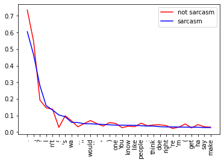

```python
compare_freq(
    sarc_lemm_nsw_freq, not_sarc_lemm_nsw_freq,
    "sarcasm", "not sarcasm",
    "blue", "red",
)
```

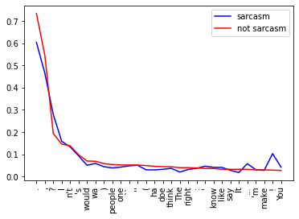

```python
compare_freq(
    not_sarc_lemm_nsw_freq, sarc_lemm_nsw_freq,
    "not sarcasm", "sarcasm",
    "red", "blue",
)
```

Una vez eliminadas las stopwords, podemos observar en ambos gráficos que las palabras en cada uno de los textos ya no presentan tantos picos, sino que la frecuencia de las mismas se vuelve similar en textos sarcásticos y no sarcásticos.

## Analisis del Uso de Mayusculas en Sarcasmo y No Sarcasmo

```python
# the "I" token was really messing the graphs
sarc_upper_tokens = [w for w in sarc_token_list if w.isupper() and w != "I"]
not_sarc_upper_tokens = [
    w for w in not_sarc_token_list if w.isupper() and w != "I"]
```

```python
"{} upper tokens from {} sarcastic ones".format(
    len(sarc_upper_tokens),
    len(sarc_token_list),
)
```

```
'1680 upper tokens from 231547 sarcastic ones'
```

```python
"while there are {} upper tokens from {} non-sarcastic ones".format(
    len(not_sarc_upper_tokens),
    len(not_sarc_token_list)
)
```

```
'while there are 1699 upper tokens from 303238 non-sarcastic ones'
```

```python
sarc_upper_freq = get_token_freq(sarc_upper_tokens)
not_sarc_upper_freq = get_token_freq(not_sarc_upper_tokens)
```

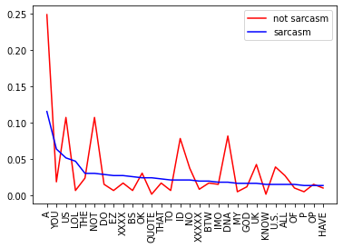

```python
compare_freq(
    sarc_upper_freq, not_sarc_upper_freq,
    "sarcasm", "not sarcasm",
    "blue", "red",
)
```

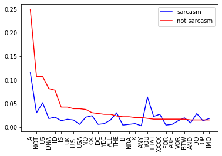

```python
compare_freq(
    not_sarc_upper_freq, sarc_upper_freq,
    "not sarcasm", "sarcasm",
    "red", "blue",
)
```

```python
sarc_upper_texts = [w.isupper() for w in sarc_df["text"]]
not_sarc_upper_texts = [w.isupper() for w in not_sarc_df["text"]]
```

Porcentaje de aparición de palabras en mayúscula en textos con sarcasmo y sin:

```python
print(len(sarc_upper_tokens)/len(sarc_token_list))
print(len(not_sarc_upper_tokens)/len(not_sarc_token_list))
```

```
0.007255546390149732
0.005602859799893153
```

Nos pareció importante conocer si existen palabras en ambos textos (sarc y no sarc) que estén escritas en mayúscula. Sin embargo, luego de los análisis realizados no encontramos información muy relevante para nuestra investigación.

## Analisis de tipo de palabras

En este punto realizaremos un análisis de palabras separándolas por grupos: sustantivos, adjetivos y adverbios. Intentaremos conocer la relación de la frecuencia de aparición de palabras que forman parte de cada uno de éstos grupos en textos sarcásticos y no sarcásticos.

```python
get_pos_tag = lambda text: nltk.pos_tag(text)
```

```python
is_noun = lambda tag: tag == 'NN'
is_adjetive = lambda tag: tag == 'JJ'
is_adverb = lambda tag: tag == 'RB'
```

```python
sarc_tagged_tokens = get_pos_tag(sarc_token_list)
not_sarc_tagged_tokens = get_pos_tag(not_sarc_token_list)
```

### Sustantivos

```python
sarc_nouns = [n for n, t in sarc_tagged_tokens if is_noun(t)]
not_sarc_nouns = [n for n, t in not_sarc_tagged_tokens if is_noun(t)]
```

```python
sarc_nouns_freq = get_token_freq(sarc_nouns)
not_sarc_nouns_freq = get_token_freq(not_sarc_nouns)
```

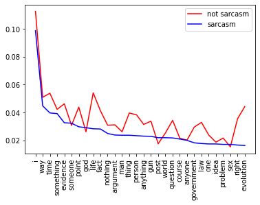

```python
compare_freq(
    sarc_nouns_freq, not_sarc_nouns_freq,
    "sarcasm", "not sarcasm",
    "blue", "red",
)
```

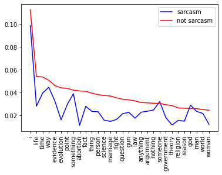

```python
compare_freq(
    not_sarc_nouns_freq, sarc_nouns_freq,
    "not sarcasm", "sarcasm",
    "red", "blue",
)
```

En el caso de los sustantivos, vemos que aparecen con mayor frecuencia en los textos no sarcásticos. Pero en este punto es importante aclarar que los textos no sarcásticos contienen mas palabras que los sarcásticos.

```python
print(len(sarc_nouns)/len(sarc_token_list))
print(len(not_sarc_nouns)/len(not_sarc_token_list))
```

```
0.12614717530350208
0.13153034909872774
```

Al haber calculado el porcentaje de aparición de sustantivos en cada tipo de texto podemos ver que son muy similares, en el caso del sarcasmo de un 12,6% y el del no sarcasmo de un 13,1%.

### Adjetivos

```python
sarc_adj = [n for n, t in sarc_tagged_tokens if is_adjetive(t)]
not_sarc_adj = [n for n, t in not_sarc_tagged_tokens if is_adjetive(t)]
```

```python
sarc_adj_freq = get_token_freq(sarc_adj)
not_sarc_adj_freq = get_token_freq(not_sarc_adj)
```

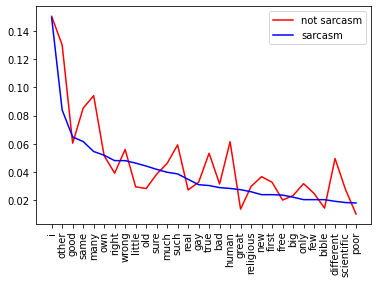

```python
compare_freq(
    sarc_adj_freq, not_sarc_adj_freq,
    "sarcasm", "not sarcasm",
    "blue", "red",
)
```

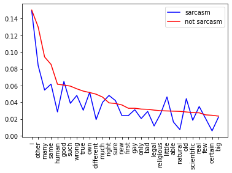

```python
compare_freq(
    not_sarc_adj_freq, sarc_adj_freq,
    "not sarcasm", "sarcasm",
    "red", "blue",
)
```

Habiendo observado los gráficos, en el caso de los adjetivos no podemos sacar conclusiones que nos ayuden a diferenciar textos sarcásticos de no sarcásticos.

### Adverbs

```python
sarc_adv = [n for n, t in sarc_tagged_tokens if is_adverb(t)]
not_sarc_adv = [n for n, t in not_sarc_tagged_tokens if is_adverb(t)]
```

```python
sarc_adv_freq = get_token_freq(sarc_adv)
not_sarc_adv_freq = get_token_freq(not_sarc_adv)
```

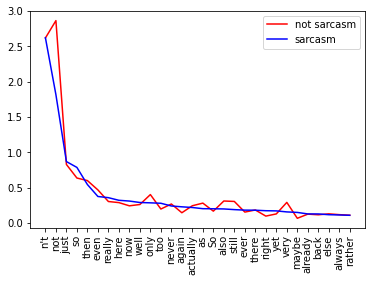

```python
compare_freq(
    sarc_adv_freq, not_sarc_adv_freq,
    "sarcasm", "not sarcasm",
    "blue", "red",
)
```

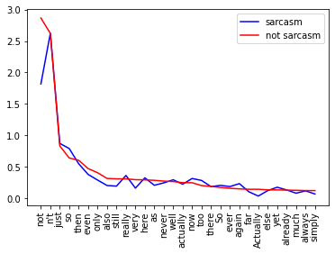

```python
compare_freq(
    not_sarc_adv_freq, sarc_adv_freq,
    "not sarcasm", "sarcasm",
    "red", "blue",
)
```

En el caso de los advervios, observamos que la frecuencia de aparición de los mismos en textos de sarcasmo y no sarcasmo es bastante similar. Por lo tanto, tampoco obtenemos acá información relevante. Si nos parece importante destacar el caso del "not", en los textos que no tienen sarcasmo se utiliza mucho mas que en los que sí lo tienen.